# INN_Learner_Notebook_Full_code_Olaolorun

### Bivariate Analysis

**Pairplot of Numerical Columns** Note: Bring all the features in the same range

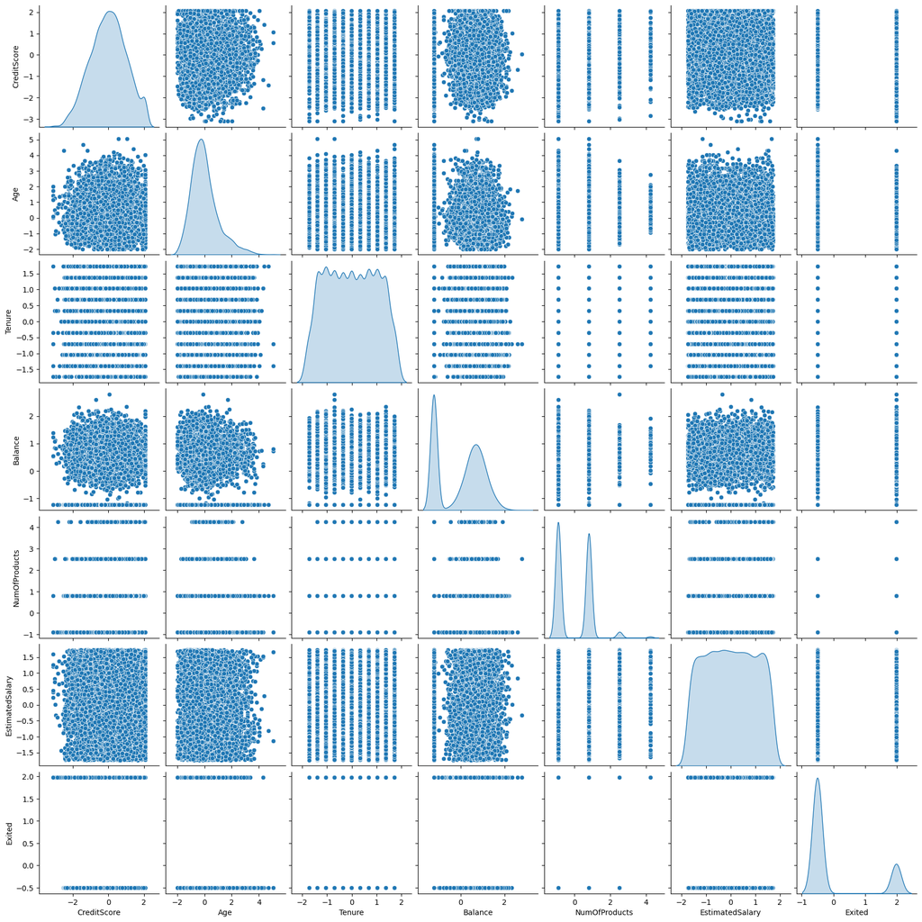

```python
## Scale the data
scaler=StandardScaler()
## Extract only the Numerical Columns to perform Bivariate Analysis
subset=df.drop(['Geography','Gender','HasCrCard','IsActiveMember'],axis=1)
scaled=scaler.fit_transform(subset)
scaled_df=pd.DataFrame(scaled,columns=subset.columns)
sns.pairplot(scaled_df,diag_kind='kde')
```

**Check Colinearity of Features**

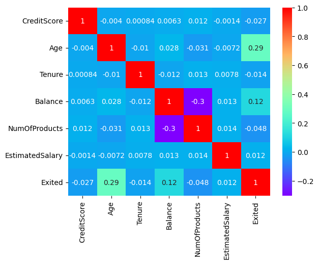

```python
sns.heatmap(scaled_df.corr(),annot=True,cmap='rainbow')
```

- There is no significant linear relationship between features

**Categorical Features vs Target Variable**

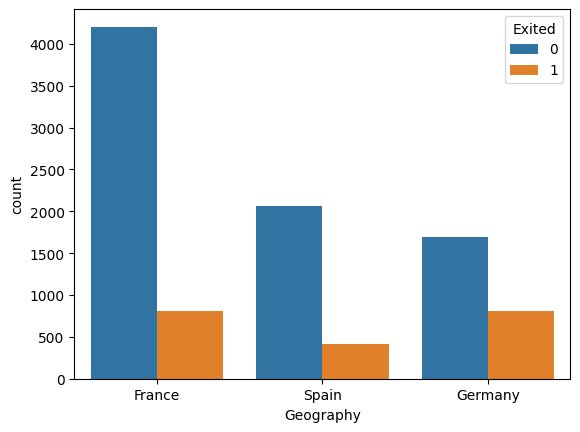

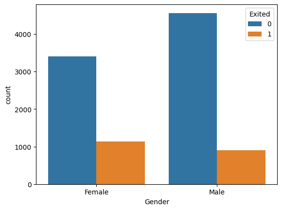

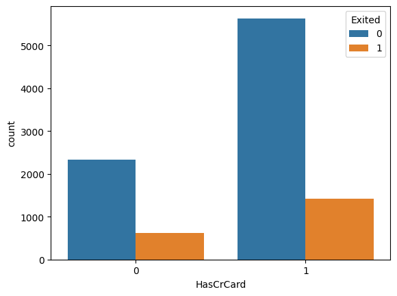

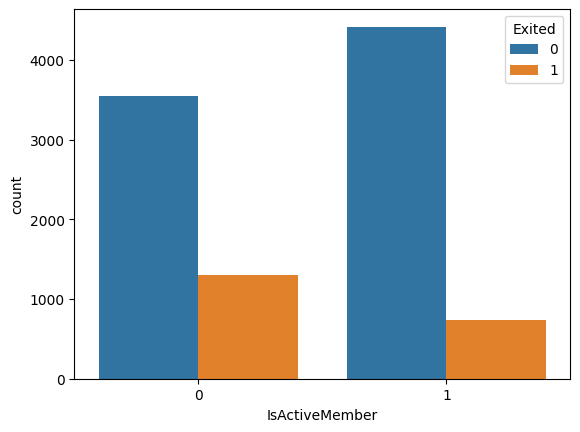

```python
## Categorical Features vs Target Variable
sns.countplot(x='Geography',data=df,hue='Exited')
plt.show()
sns.countplot(x='Gender',data=df,hue='Exited')
plt.show()
sns.countplot(x='HasCrCard',data=df,hue='Exited')
plt.show()
sns.countplot(x='IsActiveMember',data=df,hue='Exited')
plt.show()
```

**Numerical Features and Target Variable**

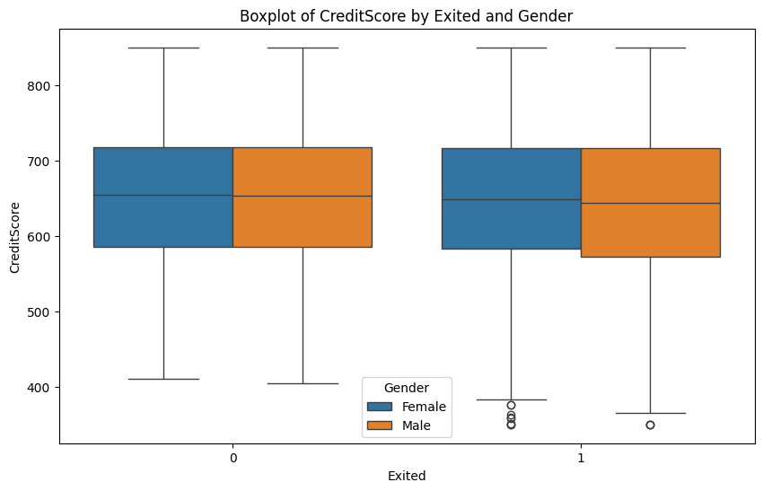

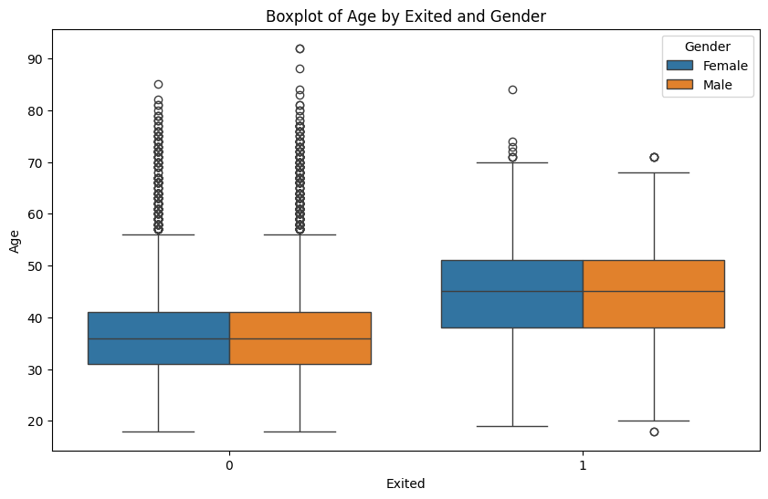

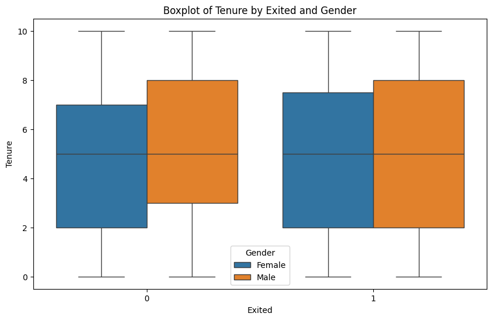

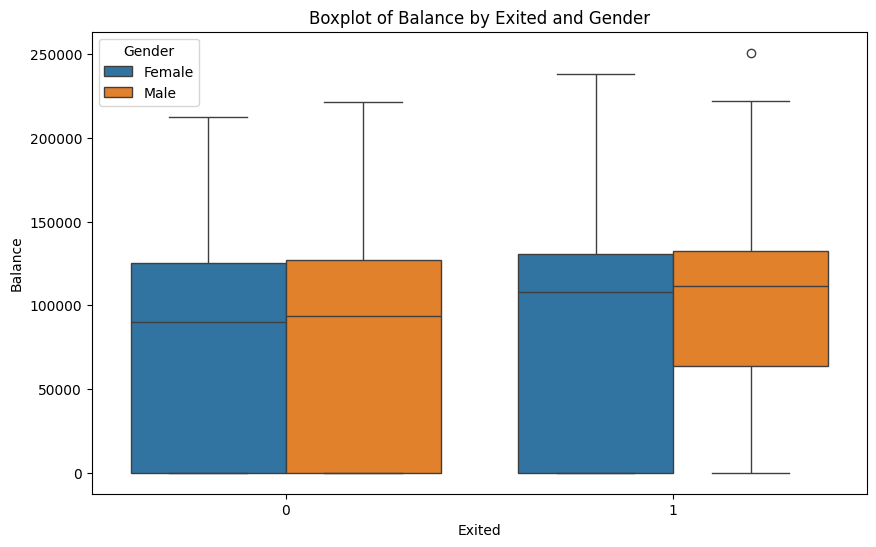

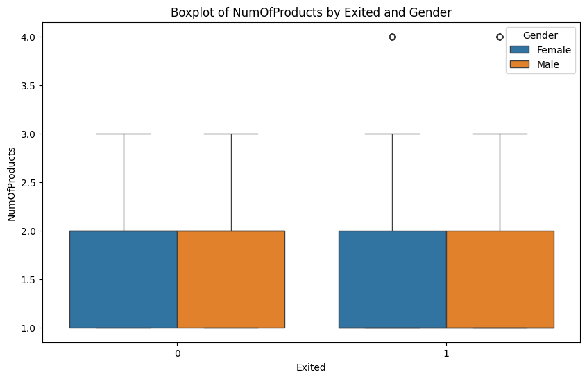

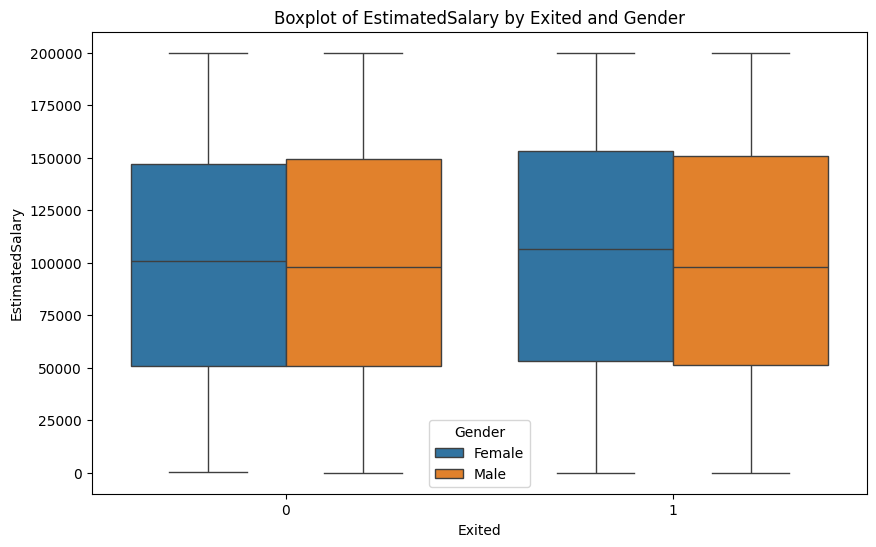

```python
subset = df.drop(['Exited','Geography','Gender','HasCrCard','IsActiveMember'], axis=1)

for i in subset.columns:
    plt.figure(figsize=(10, 6))
    sns.boxplot(x=df['Exited'], y=df[i], hue=df['Gender'])
    plt.title(f'Boxplot of {i} by Exited and Gender')
    plt.show()
```

- The Avg Credit Score seem to be almost the same for Active and Churned customers
- Young People seem to stick to the bank compared to older people
- The Average Bank Balance is high for Churned Customers
- The churning rate is high with German Customers
- The Churning rate is high among the Non-Active Members

## Data Preprocessing

```python
# Seperating Independent and Dependent variable Columns
X = df.drop(['Exited'], axis=1)
y = df['Exited']
```

```python
# Check Independent variable columns
X.columns
```

```
Index(['CreditScore', 'Geography', 'Gender', 'Age', 'Tenure', 'Balance',
       'NumOfProducts', 'HasCrCard', 'IsActiveMember', 'EstimatedSalary'],
      dtype='object')
```

### Dummy Variable Creation

```python
# Encoding the categorical variables using one-hot encoding
X = pd.get_dummies(
    X,
    columns=["Geography","Gender"],
    drop_first=True, dtype=int
)
```

```python
# View first 5 rows after performing one-hot encoding and assign int datatype to new column(s)
X.head()
```

|  | CreditScore | Age | Tenure | Balance | NumOfProducts | HasCrCard | IsActiveMember | EstimatedSalary | Geography_Germany | Geography_Spain | Gender_Male |
| --- | --- | --- | --- | --- | --- | --- | --- | --- | --- | --- | --- |
| 0 | 619 | 42 | 2 | 0.00 | 1 | 1 | 1 | 101348.88 | 0 | 0 | 0 |
| 1 | 608 | 41 | 1 | 83807.86 | 1 | 0 | 1 | 112542.58 | 0 | 1 | 0 |
| 2 | 502 | 42 | 8 | 159660.80 | 3 | 1 | 0 | 113931.57 | 0 | 0 | 0 |
| 3 | 699 | 39 | 1 | 0.00 | 2 | 0 | 0 | 93826.63 | 0 | 0 | 0 |
| 4 | 850 | 43 | 2 | 125510.82 | 1 | 1 | 1 | 79084.10 | 0 | 1 | 0 |

```python
X.info()
```

```
<class 'pandas.core.frame.DataFrame'>
RangeIndex: 10000 entries, 0 to 9999
Data columns (total 11 columns):
 #   Column             Non-Null Count  Dtype
---  ------             --------------  -----
 0   CreditScore        10000 non-null  int64
 1   Age                10000 non-null  int64
 2   Tenure             10000 non-null  int64
 3   Balance            10000 non-null  float64
 4   NumOfProducts      10000 non-null  int64
 5   HasCrCard          10000 non-null  int64
 6   IsActiveMember     10000 non-null  int64
 7   EstimatedSalary    10000 non-null  float64
 8   Geography_Germany  10000 non-null  int64
 9   Geography_Spain    10000 non-null  int64
 10  Gender_Male        10000 non-null  int64
dtypes: float64(2), int64(9)
memory usage: 859.5 KB
```

### Train-validation-test Split

```python
# Splitting the dataset into the Training and Test set.
X_train, X_test, y_train, y_test = train_test_split(X,y, test_size = 0.2, random_state = 42,stratify = y)
```

```python
# Splitting the Train dataset into the Training and Validation set.
X_train, X_valid, y_train, y_valid = train_test_split(X_train,y_train, test_size = 0.2, random_state = 42,stratify = y_train)
```

```python
#Printing the shapes.
print(X_train.shape,y_train.shape)
print(X_valid.shape,y_valid.shape)
print(X_test.shape,y_test.shape)
```

```
(6400, 11) (6400,)
(1600, 11) (1600,)
(2000, 11) (2000,)
```

### Utility Functions for checking model performances

```python
def plot(history, name):
    """
    Function to plot loss/accuracy

    history: an object which stores the metrics and losses.
    name: can be one of Loss or Accuracy
    """
    fig, ax = plt.subplots() #Creating a subplot with figure and axes.
    plt.plot(history.history[name]) #Plotting the train accuracy or train loss
    plt.plot(history.history['val_'+name]) #Plotting the validation accuracy or validation loss

    plt.title('Model ' + name.capitalize()) #Defining the title of the plot.
    plt.ylabel(name.capitalize()) #Capitalizing the first letter.
    plt.xlabel('Epoch') #Defining the label for the x-axis.
    fig.legend(['Train', 'Validation'], loc="outside right upper") #Defining the legend, loc controls the position of the legend.
```

```python
# defining a function to compute different metrics to check performance of a classification model built using statsmodels
def model_performance_classification(
    model, predictors, target, threshold=0.5
):
    """
    Function to compute different metrics to check classification model performance

    model: classifier
    predictors: independent variables
    target: dependent variable
    threshold: threshold for classifying the observation as class 1
    """

    # checking which probabilities are greater than threshold
    pred = model.predict(predictors) > threshold
    # pred_temp = model.predict(predictors) > threshold
    # # rounding off the above values to get classes
    # pred = np.round(pred_temp)

    acc = accuracy_score(target, pred)  # to compute Accuracy
    recall = recall_score(target, pred, average='weighted')  # to compute Recall
    precision = precision_score(target, pred, average='weighted')  # to compute Precision
    f1 = f1_score(target, pred, average='weighted')  # to compute F1-score

    # creating a dataframe of metrics
    df_perf = pd.DataFrame(
        {"Accuracy": acc, "Recall": recall, "Precision": precision, "F1 Score": f1,},
        index=[0],
    )

    return df_perf
```

### Data Normalization

```python
#Standardizing the numerical variables to zero mean and unit variance.
transformer = StandardScaler()
X_train[["CreditScore","Age", "Tenure", "Balance", "NumOfProducts", "EstimatedSalary"]] = transformer.fit_transform(X_train[["CreditScore","Age", "Tenure", "Balance", "NumOfProducts", "EstimatedSalary"]])
X_valid[["CreditScore","Age", "Tenure", "Balance", "NumOfProducts", "EstimatedSalary"]] = transformer.fit_transform(X_valid[["CreditScore","Age", "Tenure", "Balance", "NumOfProducts", "EstimatedSalary"]])
X_test[["CreditScore","Age", "Tenure", "Balance", "NumOfProducts", "EstimatedSalary"]] = transformer.fit_transform(X_test[["CreditScore","Age", "Tenure", "Balance", "NumOfProducts", "EstimatedSalary"]])
```

## Model Building

### Model Evaluation Criterion

**A model can make wrong predictions in the following ways:**

- Predicting that a customer will churn when they will not (False Positive).
- Predicting that a customer will not churn when they will (False Negative).

**Which case is more important?**

Both cases are critically important for the bank. Misclassifying customers in either way can have significant consequences:

- **False Positives**: Predicting that a customer will churn when they actually will not can lead to unnecessary retention efforts and resources being spent on customers who were not at risk of leaving. This could include offering discounts, special deals, or other incentives, which represent a financial cost to the bank without corresponding benefits.
- **False Negatives**: Predicting that a customer will not churn when they actually will means the bank misses the opportunity to intervene and retain a valuable customer. This can result in lost revenue and the cost of acquiring a new customer to replace the one lost.

**How to reduce this loss i.e need to reduce False Negatives as well as False Positives?**

To address the issue effectively, the bank should aim to **maximize the F1 Score** of the predictive model. The **F1 Score** is a metric that considers both precision (the accuracy of positive predictions) and recall (the ability to capture actual positives), providing a balanced evaluation of the model's performance.

### Treat Imbalance in class distirbution

```python
# Calculate class weights for imbalanced dataset
cw = (y_train.shape[0]) / np.bincount(y_train)

# Create a dictionary mapping class indices to their respective class weights
cw_dict = {}
for i in range(cw.shape[0]):
    cw_dict[i] = cw[i]

cw_dict
```

```
{0: 1.2558869701726845, 1: 4.9079754601226995}
```

```python
# defining the batch size and # epochs upfront as we'll be using the same values for all models
epochs = 25
batch_size = 64
```

### Neural Network with SGD Optimizer

#### **Model 0**

Let's start with a neural network consisting of:

- two hidden layers with 14 and 7 neurons respectively
- activation function of ReLU.
- SGD as the optimizer

```python
# clears the current Keras session, resetting all layers and models previously created, freeing up memory and resources.
tf.keras.backend.clear_session()
```

```python
#Initializing the neural network
model = Sequential()
model.add(Dense(14,activation="relu",input_dim=X_train.shape[1]))
model.add(Dense(7,activation="relu"))
model.add(Dense(1,activation="sigmoid"))
```

```python
model.summary()
```

```
Model: "sequential"
_________________________________________________________________
 Layer (type)                Output Shape              Param #
=================================================================
 dense (Dense)               (None, 14)                168

 dense_1 (Dense)             (None, 7)                 105

 dense_2 (Dense)             (None, 1)                 8

=================================================================
Total params: 281 (1.10 KB)
Trainable params: 281 (1.10 KB)
Non-trainable params: 0 (0.00 Byte)
_________________________________________________________________
```

```python
optimizer = tf.keras.optimizers.SGD()    # defining SGD as the optimizer to be used
model.compile(loss='binary_crossentropy', optimizer=optimizer)
```

```python
start = time.time()
history = model.fit(X_train, y_train, validation_data=(X_valid,y_valid) , batch_size=batch_size, epochs=epochs,class_weight=cw_dict)
end=time.time()
```

```python
print("Time taken in seconds ",end-start)
```

```
Time taken in seconds  11.005386590957642
```

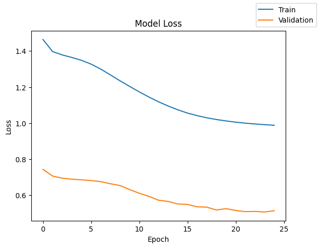

```python
plot(history,'loss')
```

```python
model_0_train_perf = model_performance_classification(model, X_train, y_train)
model_0_train_perf
```

|  | Accuracy | Recall | Precision | F1 Score |
| --- | --- | --- | --- | --- |
| 0 | 0.754062 | 0.754062 | 0.827223 | 0.774403 |

```python
model_0_valid_perf = model_performance_classification(model, X_valid, y_valid)
model_0_valid_perf
```

|  | Accuracy | Recall | Precision | F1 Score |
| --- | --- | --- | --- | --- |
| 0 | 0.7375 | 0.7375 | 0.824773 | 0.760591 |

- Train F1 score of ~0.77 and test F1 score of ~0.76 indicate consistent performance of the model between training and testing datasets.

## Model Performance Improvement

### Neural Network with Adam Optimizer

#### **Model 1**

```python
# clears the current Keras session, resetting all layers and models previously created, freeing up memory and resources.
tf.keras.backend.clear_session()
```

```python
#Initializing the neural network
model = Sequential()
model.add(Dense(14,activation="relu",input_dim=X_train.shape[1]))
model.add(Dense(7,activation="relu"))
model.add(Dense(1,activation="sigmoid"))
```

```python
model.summary()
```

```
Model: "sequential"
_________________________________________________________________
 Layer (type)                Output Shape              Param #
=================================================================
 dense (Dense)               (None, 14)                168

 dense_1 (Dense)             (None, 7)                 105

 dense_2 (Dense)             (None, 1)                 8

=================================================================
Total params: 281 (1.10 KB)
Trainable params: 281 (1.10 KB)
Non-trainable params: 0 (0.00 Byte)
_________________________________________________________________
```

```python
optimizer = tf.keras.optimizers.Adam()    # defining Adam as the optimizer to be used
model.compile(loss='binary_crossentropy', optimizer=optimizer)
```

```python
start = time.time()
history = model.fit(X_train, y_train, validation_data=(X_valid,y_valid) , batch_size=batch_size, epochs=epochs,class_weight=cw_dict)
end=time.time()
```

```python
print("Time taken in seconds ",end-start)
```

```
Time taken in seconds  10.068617105484009
```

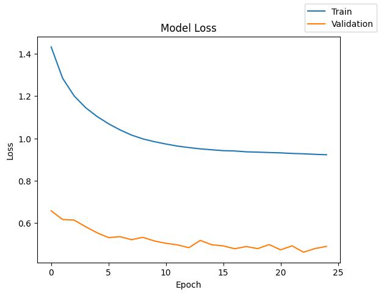

```python
plot(history,'loss')
```

```python
model_1_train_perf = model_performance_classification(model, X_train, y_train)
model_1_train_perf
```

|  | Accuracy | Recall | Precision | F1 Score |
| --- | --- | --- | --- | --- |
| 0 | 0.777813 | 0.777813 | 0.839582 | 0.795102 |

```python
model_1_valid_perf = model_performance_classification(model, X_valid, y_valid)
model_1_valid_perf
```

|  | Accuracy | Recall | Precision | F1 Score |
| --- | --- | --- | --- | --- |
| 0 | 0.76 | 0.76 | 0.831542 | 0.779726 |

### Neural Network with Adam Optimizer and Dropout

#### **Model 2**

```python
# clears the current Keras session, resetting all layers and models previously created, freeing up memory and resources.
tf.keras.backend.clear_session()
```

```python
#Initializing the neural network with dropouts
model = Sequential()
model.add(Dense(14,activation="relu",input_dim=X_train.shape[1]))
model.add(Dropout(0.4))
model.add(Dense(7,activation="relu"))
model.add(Dropout(0.2))
model.add(Dense(1,activation="sigmoid"))
```

```python
model.summary()
```

```
Model: "sequential"
_________________________________________________________________
 Layer (type)                Output Shape              Param #
=================================================================
 dense (Dense)               (None, 14)                168

 dropout (Dropout)           (None, 14)                0

 dense_1 (Dense)             (None, 7)                 105

 dropout_1 (Dropout)         (None, 7)                 0

 dense_2 (Dense)             (None, 1)                 8

=================================================================
Total params: 281 (1.10 KB)
Trainable params: 281 (1.10 KB)
Non-trainable params: 0 (0.00 Byte)
_________________________________________________________________
```

```python
optimizer = tf.keras.optimizers.Adam()    # defining Adam as the optimizer to be used
model.compile(loss='binary_crossentropy', optimizer=optimizer)
```

```python
start = time.time()
history = model.fit(X_train, y_train, validation_data=(X_valid,y_valid) , batch_size=batch_size, epochs=epochs,class_weight=cw_dict)
end=time.time()
```

```python
print("Time taken in seconds ",end-start)
```

```
Time taken in seconds  21.3782057762146
```

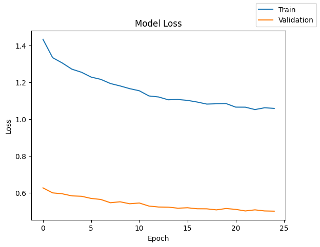

```python
plot(history,'loss')
```

```python
model_2_train_perf = model_performance_classification(model, X_train, y_train)
model_2_train_perf
```

|  | Accuracy | Recall | Precision | F1 Score |
| --- | --- | --- | --- | --- |
| 0 | 0.7925 | 0.7925 | 0.837853 | 0.806433 |

```python
model_2_valid_perf = model_performance_classification(model, X_valid, y_valid)
model_2_valid_perf
```

|  | Accuracy | Recall | Precision | F1 Score |
| --- | --- | --- | --- | --- |
| 0 | 0.769375 | 0.769375 | 0.825515 | 0.786366 |

### Neural Network with Balanced Data (by applying SMOTE) and SGD Optimizer

#### **Model 3**

```python
# Fit SMOTE on train data(Synthetic Minority Oversampling Technique)
sm = SMOTE(sampling_strategy='auto', k_neighbors=5, random_state=1)
X_train_over, y_train_over = sm.fit_resample(X_train, y_train)
```

```python
print("Before OverSampling, count of label '1': {}".format(sum(y_train == 1)))
print("Before OverSampling, count of label '0': {} \n".format(sum(y_train == 0)))

print("After OverSampling, count of label '1': {}".format(sum(y_train_over == 1)))
print("After OverSampling, count of label '0': {} \n".format(sum(y_train_over == 0)))

print("After OverSampling, the shape of train_X: {}".format(X_train_over.shape))
print("After OverSampling, the shape of train_y: {} \n".format(y_train_over.shape))
```

```
Before OverSampling, count of label '1': 1304
Before OverSampling, count of label '0': 5096

After OverSampling, count of label '1': 5096
After OverSampling, count of label '0': 5096

After OverSampling, the shape of train_X: (10192, 11)
After OverSampling, the shape of train_y: (10192,)
```

```python
# clears the current Keras session, resetting all layers and models previously created, freeing up memory and resources.
tf.keras.backend.clear_session()
```

```python
#Initializing the neural network
model = Sequential()
model.add(Dense(14,activation="relu",input_dim=X_train_over.shape[1]))
model.add(Dense(7,activation="relu"))
model.add(Dense(1,activation="sigmoid"))
```

```python
model.summary()
```

```
Model: "sequential"
_________________________________________________________________
 Layer (type)                Output Shape              Param #
=================================================================
 dense (Dense)               (None, 14)                168

 dense_1 (Dense)             (None, 7)                 105

 dense_2 (Dense)             (None, 1)                 8

=================================================================
Total params: 281 (1.10 KB)
Trainable params: 281 (1.10 KB)
Non-trainable params: 0 (0.00 Byte)
_________________________________________________________________
```

```python
optimizer = tf.keras.optimizers.SGD()    # defining SGD as the optimizer to be used
model.compile(loss='binary_crossentropy', optimizer=optimizer)
```

```python
start = time.time()
history = model.fit(X_train_over, y_train_over, validation_data=(X_valid,y_valid) , batch_size=batch_size, epochs=epochs,class_weight=cw_dict)
end=time.time()
```

```python
print("Time taken in seconds ",end-start)
```

```
Time taken in seconds  16.15897274017334
```

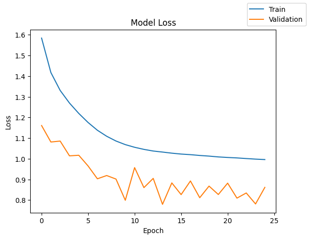

```python
plot(history,'loss')
```

```python
model_3_train_perf = model_performance_classification(model, X_train_over, y_train_over)
model_3_train_perf
```

|  | Accuracy | Recall | Precision | F1 Score |
| --- | --- | --- | --- | --- |
| 0 | 0.723116 | 0.723116 | 0.787668 | 0.70666 |

```python
model_3_valid_perf = model_performance_classification(model, X_valid, y_valid)
model_3_valid_perf
```

|  | Accuracy | Recall | Precision | F1 Score |
| --- | --- | --- | --- | --- |
| 0 | 0.558125 | 0.558125 | 0.828924 | 0.591958 |

- The F1 scores for both the train and validation sets are lower.
- Additionally, the difference in both scores are significant, indicating inconsistent performance

### Neural Network with Balanced Data (by applying SMOTE) and Adam Optimizer

#### **Model 4**

```python
# Fit SMOTE on train data(Synthetic Minority Oversampling Technique)
sm = SMOTE(sampling_strategy='auto', k_neighbors=5, random_state=1)
X_train_over, y_train_over = sm.fit_resample(X_train, y_train)
```

```python
print("Before OverSampling, count of label '1': {}".format(sum(y_train == 1)))
print("Before OverSampling, count of label '0': {} \n".format(sum(y_train == 0)))

print("After OverSampling, count of label '1': {}".format(sum(y_train_over == 1)))
print("After OverSampling, count of label '0': {} \n".format(sum(y_train_over == 0)))

print("After OverSampling, the shape of train_X: {}".format(X_train_over.shape))
print("After OverSampling, the shape of train_y: {} \n".format(y_train_over.shape))
```

```
Before OverSampling, count of label '1': 1304
Before OverSampling, count of label '0': 5096

After OverSampling, count of label '1': 5096
After OverSampling, count of label '0': 5096

After OverSampling, the shape of train_X: (10192, 11)
After OverSampling, the shape of train_y: (10192,)
```

```python
# clears the current Keras session, resetting all layers and models previously created, freeing up memory and resources.
tf.keras.backend.clear_session()
```

```python
#Initializing the neural network
model = Sequential()
model.add(Dense(14,activation="relu",input_dim=X_train_over.shape[1]))
model.add(Dense(7,activation="relu"))
model.add(Dense(1,activation="sigmoid"))
```

```python
model.summary()
```

```
Model: "sequential"
_________________________________________________________________
 Layer (type)                Output Shape              Param #
=================================================================
 dense (Dense)               (None, 14)                168

 dense_1 (Dense)             (None, 7)                 105

 dense_2 (Dense)             (None, 1)                 8

=================================================================
Total params: 281 (1.10 KB)
Trainable params: 281 (1.10 KB)
Non-trainable params: 0 (0.00 Byte)
_________________________________________________________________
```

```python
optimizer = tf.keras.optimizers.Adam()    # defining Adam as the optimizer to be used
model.compile(loss='binary_crossentropy', optimizer=optimizer)
```

```python
start = time.time()
history = model.fit(X_train_over, y_train_over, validation_data=(X_valid,y_valid) , batch_size=batch_size, epochs=epochs,class_weight=cw_dict)
end=time.time()
```

```python
print("Time taken in seconds ",end-start)
```

```
Time taken in seconds  21.358052492141724
```

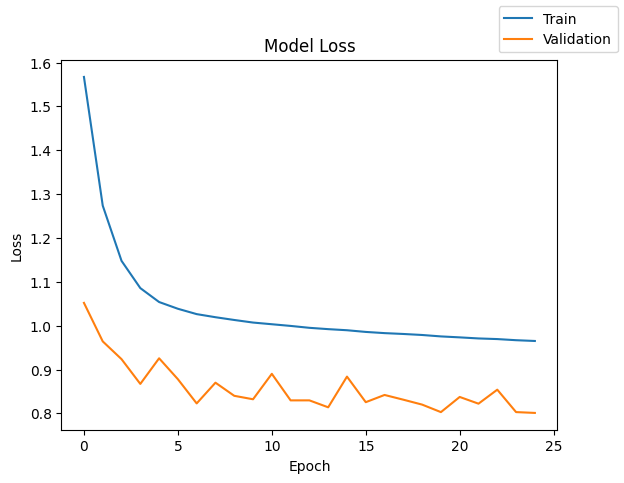

```python
plot(history,'loss')
```

```python
model_4_train_perf = model_performance_classification(model, X_train_over, y_train_over)
model_4_train_perf
```

|  | Accuracy | Recall | Precision | F1 Score |
| --- | --- | --- | --- | --- |
| 0 | 0.746075 | 0.746075 | 0.798166 | 0.734479 |

```python
model_4_valid_perf = model_performance_classification(model, X_valid, y_valid)
model_4_valid_perf
```

|  | Accuracy | Recall | Precision | F1 Score |
| --- | --- | --- | --- | --- |
| 0 | 0.59875 | 0.59875 | 0.829283 | 0.633887 |

- The F1 scores for both the train and validation sets are higher compared with SGD optimizer.
- Also, the difference in both scores got closer.

### Neural Network with Balanced Data (by applying SMOTE), Adam Optimizer, and Dropout

#### **Model 5**

```python
# Fit SMOTE on train data(Synthetic Minority Oversampling Technique)
sm = SMOTE(sampling_strategy='auto', k_neighbors=5, random_state=1)
X_train_over, y_train_over = sm.fit_resample(X_train, y_train)
```

```python
print("Before OverSampling, count of label '1': {}".format(sum(y_train == 1)))
print("Before OverSampling, count of label '0': {} \n".format(sum(y_train == 0)))

print("After OverSampling, count of label '1': {}".format(sum(y_train_over == 1)))
print("After OverSampling, count of label '0': {} \n".format(sum(y_train_over == 0)))

print("After OverSampling, the shape of train_X: {}".format(X_train_over.shape))
print("After OverSampling, the shape of train_y: {} \n".format(y_train_over.shape))
```

```
Before OverSampling, count of label '1': 1304
Before OverSampling, count of label '0': 5096

After OverSampling, count of label '1': 5096
After OverSampling, count of label '0': 5096

After OverSampling, the shape of train_X: (10192, 11)
After OverSampling, the shape of train_y: (10192,)
```

```python
# clears the current Keras session, resetting all layers and models previously created, freeing up memory and resources.
tf.keras.backend.clear_session()
```

```python
#Initializing the neural network with dropouts
model = Sequential()
model.add(Dense(14,activation="relu",input_dim=X_train_over.shape[1]))
model.add(Dropout(0.4))
model.add(Dense(7,activation="relu"))
model.add(Dropout(0.2))
model.add(Dense(1,activation="sigmoid"))
```

```python
model.summary()
```

```
Model: "sequential"
_________________________________________________________________
 Layer (type)                Output Shape              Param #
=================================================================
 dense (Dense)               (None, 14)                168

 dropout (Dropout)           (None, 14)                0

 dense_1 (Dense)             (None, 7)                 105

 dropout_1 (Dropout)         (None, 7)                 0

 dense_2 (Dense)             (None, 1)                 8

=================================================================
Total params: 281 (1.10 KB)
Trainable params: 281 (1.10 KB)
Non-trainable params: 0 (0.00 Byte)
_________________________________________________________________
```

```python
optimizer = tf.keras.optimizers.Adam()    # defining Adam as the optimizer to be used
model.compile(loss='binary_crossentropy', optimizer=optimizer)
```

```python
start = time.time()
history = model.fit(X_train_over, y_train_over, validation_data=(X_valid,y_valid) , batch_size=batch_size, epochs=epochs,class_weight=cw_dict)
end=time.time()
```

```python
print("Time taken in seconds ",end-start)
```

```
Time taken in seconds  21.53624391555786
```

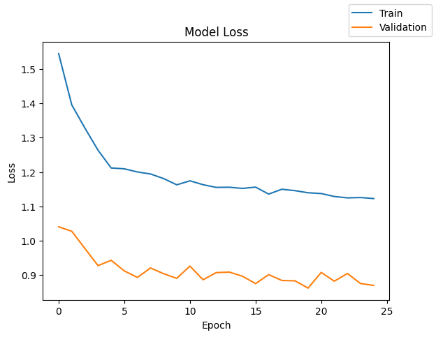

```python
plot(history,'loss')
```

```python
model_5_train_perf = model_performance_classification(model, X_train_over, y_train_over)
model_5_train_perf
```

|  | Accuracy | Recall | Precision | F1 Score |
| --- | --- | --- | --- | --- |
| 0 | 0.718407 | 0.718407 | 0.787194 | 0.700471 |

```python
model_5_valid_perf = model_performance_classification(model, X_valid, y_valid)
model_5_valid_perf
```

|  | Accuracy | Recall | Precision | F1 Score |
| --- | --- | --- | --- | --- |
| 0 | 0.544375 | 0.544375 | 0.827775 | 0.577329 |

- The F1 scores for both the train and validation sets are lower compared with ADAM optimizer without dropout.
- Also, the difference in both scores is not better as well.

## Model Performance Comparison and Final Model Selection

```python
# training performance comparison

models_train_comp_df = pd.concat(
    [
        model_0_train_perf.T,
        model_1_train_perf.T,
        model_2_train_perf.T,
        model_3_train_perf.T,
        model_4_train_perf.T,
        model_5_train_perf.T
    ],
    axis=1,
)
models_train_comp_df.columns = [
    "Neural Network (SGD Optimizer)",
    "Neural Network (Adam Optimizer)",
    "Neural Network (Adam Optimizer, Drop Out[0.4,0.2])",
    "Neural Network (SGD, SMOTE)",
    "Neural Network (Adam, SMOTE)",
    "Neural Network (Adam,dropout [0.4,0.2] ,Adam optimizer)",
]
```

```python
# Validation performance comparison

models_valid_comp_df = pd.concat(
    [
        model_0_valid_perf.T,
        model_1_valid_perf.T,
        model_2_valid_perf.T,
        model_3_valid_perf.T,
        model_4_valid_perf.T,
        model_5_valid_perf.T
    ],
    axis=1,
)
models_valid_comp_df.columns = [
    "Neural Network (SGD Optimizer)",
    "Neural Network (Adam Optimizer)",
    "Neural Network (Adam Optimizer, Drop Out[0.4,0.2])",
    "Neural Network (SGD, SMOTE)",
    "Neural Network (Adam, SMOTE)",
    "Neural Network (Adam,dropout [0.4,0.2] ,Adam optimizer)",
]
```

```python
models_train_comp_df
```

|  | Neural Network (SGD Optimizer) | Neural Network (Adam Optimizer) | Neural Network (Adam Optimizer, Drop Out[0.4,0.2]) | Neural Network (SGD, SMOTE) | Neural Network (Adam, SMOTE) | Neural Network (Adam,dropout [0.4,0.2] ,Adam optimizer) |
| --- | --- | --- | --- | --- | --- | --- |
| Accuracy | 0.754062 | 0.777813 | 0.792500 | 0.723116 | 0.746075 | 0.718407 |
| Recall | 0.754062 | 0.777813 | 0.792500 | 0.723116 | 0.746075 | 0.718407 |
| Precision | 0.827223 | 0.839582 | 0.837853 | 0.787668 | 0.798166 | 0.787194 |
| F1 Score | 0.774403 | 0.795102 | 0.806433 | 0.706660 | 0.734479 | 0.700471 |

```python
models_valid_comp_df
```

|  | Neural Network (SGD Optimizer) | Neural Network (Adam Optimizer) | Neural Network (Adam Optimizer, Drop Out[0.4,0.2]) | Neural Network (SGD, SMOTE) | Neural Network (Adam, SMOTE) | Neural Network (Adam,dropout [0.4,0.2] ,Adam optimizer) |
| --- | --- | --- | --- | --- | --- | --- |
| Accuracy | 0.737500 | 0.760000 | 0.769375 | 0.558125 | 0.598750 | 0.544375 |
| Recall | 0.737500 | 0.760000 | 0.769375 | 0.558125 | 0.598750 | 0.544375 |
| Precision | 0.824773 | 0.831542 | 0.825515 | 0.828924 | 0.829283 | 0.827775 |
| F1 Score | 0.760591 | 0.779726 | 0.786366 | 0.591958 | 0.633887 | 0.577329 |

```python
models_train_comp_df.loc["F1 Score"] - models_valid_comp_df.loc["F1 Score"]
```

```
Neural Network (SGD Optimizer)                             0.013812
Neural Network (Adam Optimizer)                            0.015375
Neural Network (Adam Optimizer, Drop Out[0.4,0.2])         0.020066
Neural Network (SGD, SMOTE)                                0.114702
Neural Network (Adam, SMOTE)                               0.100591
Neural Network (Adam,dropout [0.4,0.2] ,Adam optimizer)    0.123142
Name: F1 Score, dtype: float64
```

### Final Model

Neural network consisting of:

two hidden layers with 14 and 7 neurons respectively activation function of ReLU. Adam as the optimizer

```python
# clears the current Keras session, resetting all layers and models previously created, freeing up memory and resources.
tf.keras.backend.clear_session()
```

```python
#Initializing the neural network
model = Sequential()
model.add(Dense(14,activation="relu",input_dim=X_train.shape[1]))
model.add(Dense(7,activation="relu"))
model.add(Dense(1,activation="sigmoid"))
```

```python
model.summary()
```

```
Model: "sequential"
_________________________________________________________________
 Layer (type)                Output Shape              Param #
=================================================================
 dense (Dense)               (None, 14)                168

 dense_1 (Dense)             (None, 7)                 105

 dense_2 (Dense)             (None, 1)                 8

=================================================================
Total params: 281 (1.10 KB)
Trainable params: 281 (1.10 KB)
Non-trainable params: 0 (0.00 Byte)
_________________________________________________________________
```

```python
optimizer = tf.keras.optimizers.Adam()    # defining Adam as the optimizer to be used
model.compile(loss='binary_crossentropy', optimizer=optimizer)
```

```python
start = time.time()
history = model.fit(X_train, y_train, validation_data=(X_valid,y_valid) , batch_size=batch_size, epochs=epochs,class_weight=cw_dict)
end=time.time()
```

```python
y_train_pred = model.predict(X_train)
y_valid_pred = model.predict(X_valid)
y_test_pred = model.predict(X_test)
```

```python
print("Classification Report - Train data",end="\n\n")
cr = classification_report(y_train,y_train_pred>0.5)
print(cr)
```

```
Classification Report - Train data

              precision    recall  f1-score   support

           0       0.93      0.78      0.85      5096
           1       0.47      0.78      0.59      1304

    accuracy                           0.78      6400
   macro avg       0.70      0.78      0.72      6400
weighted avg       0.84      0.78      0.79      6400
```

```python
print("Classification Report - Validation data",end="\n\n")
cr = classification_report(y_valid,y_valid_pred>0.5)
print(cr)
```

```
Classification Report - Validation data

              precision    recall  f1-score   support

           0       0.93      0.75      0.83      1274
           1       0.44      0.77      0.56       326

    accuracy                           0.76      1600
   macro avg       0.69      0.76      0.70      1600
weighted avg       0.83      0.76      0.78      1600
```

```python
print("Classification Report - Test data",end="\n\n")
cr = classification_report(y_test,y_test_pred>0.5)
print(cr)
```

```
Classification Report - Test data

              precision    recall  f1-score   support

           0       0.93      0.76      0.83      1593
           1       0.45      0.78      0.57       407

    accuracy                           0.76      2000
   macro avg       0.69      0.77      0.70      2000
weighted avg       0.83      0.76      0.78      2000
```

## Actionable Insights and Business Recommendations

- The bank can deploy the final model from this exercise to identify with a reasonable degree of accuracy whether a customer is likely to leave or not, and this process seems to be easier and more time-efficient than other methods.
- Given that the average bank balance is high among churned customers, the bank should implement a strategy to incentivize these customers to remain with the bank. For instance, the bank could offer an annual percentage interest on the balances of customers who maintain their accounts with the bank.
- The bank should prioritize offering financial products and services that cater specifically to the needs of older customers, such as retirement planning, investment advice, and savings accounts with higher interest rates. Additionally, ensure that online and mobile banking platforms are user-friendly and accessible for older customers.
- The bank should develop and implement marketing campaigns that are culturally relevant and tailored to the preferences of German customers as well as provide dedicated customer support in the German language to ensure effective communication and customer satisfaction.
- For non-active members, the bank should keep them informed with personalized messages and updates through multiple communication channels. They should ensure that the bank’s online and mobile platforms are intuitive and easy to navigate, providing support as needed. Additionally, they should implement a robust feedback mechanism to gather insights from non-active members and address any barriers to their engagement.

Power Ahead